# analyzing-data-in-science-analysis

## Prepping, loading, setting up

```r
library(tidyverse)
library(googlesheets4)

d <- read_sheet("https://docs.google.com/spreadsheets/d/1gLyAAp6N_5g-Uo-eb61O-eW2apMzzqNdM8fLcBV7V3g/edit#gid=46458265",
                sheet = 1)

qual_q80 <- read_sheet("https://docs.google.com/spreadsheets/d/1gLyAAp6N_5g-Uo-eb61O-eW2apMzzqNdM8fLcBV7V3g/edit#gid=46458265",
                       sheet = "Q 80 - MASTER")

qual_q80 <- qual_q80 %>% janitor::clean_names()

names(qual_q80) <- str_c("qual_q80_", names(qual_q80))

names(qual_q80)[1] <- "response_id"

d <- d %>%
  left_join(qual_q80)
```

## RQ 1

How do teachers support their students to analyze and interpret data?

### open coding - Q80 overall

qualitatively coded based on open/written responses to Q80

```r
overall_freqs <- d %>%
  select(contains("qual_q80")) %>%
  select(-c(1, 9)) %>%
  summarize_all(sum, na.rm = T) %>%
  gather(key, val) %>%
  mutate(prop = val/328) %>%
  arrange(desc(val))

overall_freqs %>%
  mutate(prop = prop * 100) %>%
  mutate_if(is.numeric, round, 3) %>%
  select(-val) %>%
  knitr::kable()
```

| key | prop |
| --- | --- |
| qual_q80_data_visualization_graph_creation | 49.695 |
| qual_q80_data_interpretation_identify_and_interpret_a_graph_or_data_looking_for_patterns | 39.329 |
| qual_q80_data_collection_their_own_or_finding_data_recording_first_hand_data | 35.061 |
| qual_q80_data_summary_summary_table_averaging_math_tasks | 27.439 |
| qual_q80_other_those_that_dont_fit_into_other_categories_modeling | 21.341 |
| qual_q80_data_application_answering_question_cer_explanations_comparing | 20.732 |
| qual_q80_data_curation_tables_organizing_entering_already_collected_or_recorded_data_tidy_data | 15.244 |

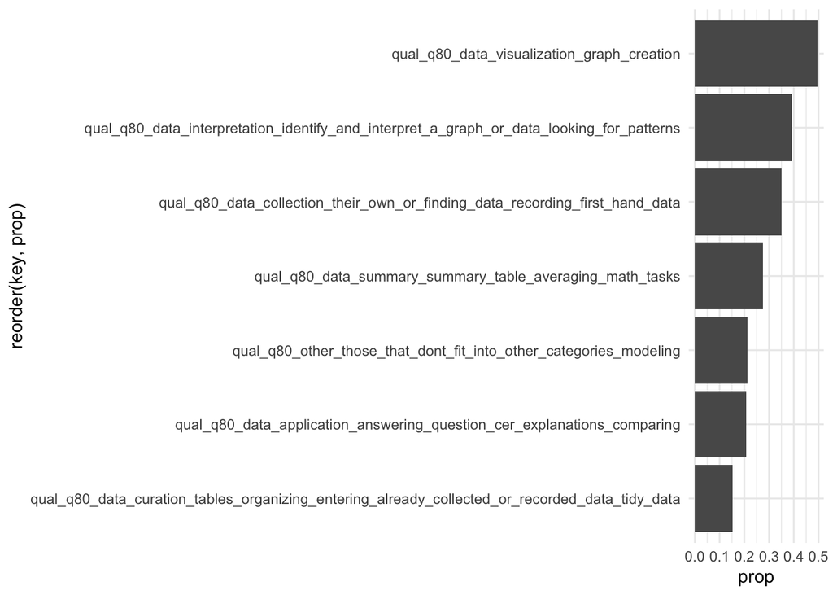

```r
overall_freqs %>%
  ggplot(aes(x = reorder(key, prop), y = prop)) +
  geom_col() +
  theme_minimal() +
  coord_flip()
```

### fixed response question– NSSME

## 4 overlapping

3 maybe overlapping/overlapping a little 2 not

Q98: How often do you have students do each of the following in your class?

1. Determine which data would need to be collected in order to answer a scientific question (regardless of who generated the question) (1) – YES
2. Determine which variables from a provided dataset are necessary to answer a scientific question (13) – MAYBE
3. Organize and/or represent data using tables, charts, or graphs in order to facilitate analysis (4) – YES
4. Identify potential sources of variability (e.g., measurement error, natural variation) in the data (5) – MAYBE
5. Analyze data using grade-appropriate methods in order to identify patterns, trends, or relationships (6) – YES
6. Consider how missing data or measurement error can affect data interpretation (7) – NOT
7. Select and use grade-appropriate mathematical and/or statistical techniques to analyze data (for example: determining the best measure of central tendency, examining variation in data, or developing a line of best fit) (9) – YES
8. Use mathematical and/or computational models to generate data to support a scientific claim (10) – NO
9. Use data and reasoning to defend, verbally or in writing, a claim or refute alternative scientific claims about a real-world phenomenon (regardless of who made the claims) (11) – MAYBE

```r
d %>%
  select(q98_1:q98_9) %>%
  gather(key, val) %>%
  count(key, val) %>%
  filter(val != "NA") %>%
  # Calculate total counts per key for percentage calculation
  group_by(key) %>%
  mutate(total_n = sum(n)) %>%
  ungroup() %>%
  # Calculate the percentage for each val
  mutate(percentage = (n / total_n) * 100) %>%
  # Reorder based on "All or almost all science lessons"
  group_by(key) %>%
  mutate(order_var = sum(n[val == "All or almost all science lessons"], na.rm = TRUE)) %>%
  ungroup() %>%
  arrange(desc(order_var)) %>%
  # Use the label map for renaming keys
  mutate(key = fct_reorder(key, order_var, .desc = TRUE),
         val = factor(val, levels = c(
           "All or almost all science lessons",
           "Often (once or twice a week)",
           "Sometimes (once or twice a month)",
           "Rarely (a few times a year)",
           "Never"))) %>%
  select(key, val, percentage) %>%
  spread(val, percentage) %>%
  mutate_if(is.numeric, round, 3) %>%
  knitr::kable()
```

| key | All or almost all science lessons | Often (once or twice a week) | Sometimes (once or twice a month) | Rarely (a few times a year) | Never |
| --- | --- | --- | --- | --- | --- |
| q98_9 | 9.756 | 36.280 | 39.329 | 11.890 | 2.744 |
| q98_5 | 7.927 | 42.378 | 39.939 | 8.841 | 0.915 |
| q98_3 | 7.012 | 42.378 | 43.598 | 6.707 | 0.305 |
| q98_1 | 4.573 | 16.463 | 44.817 | 32.317 | 1.829 |
| q98_6 | 3.049 | 16.463 | 38.415 | 33.841 | 8.232 |
| q98_8 | 3.049 | 19.512 | 37.805 | 25.000 | 14.634 |
| q98_2 | 2.744 | 23.171 | 46.951 | 24.085 | 3.049 |
| q98_4 | 2.439 | 24.085 | 42.073 | 24.695 | 6.707 |
| q98_7 | 2.439 | 18.293 | 34.756 | 32.317 | 12.195 |

## RQ2 - demographics

How does this support differe based on teachers’ grade, level of training and experience, and the subject they teach?

*we use what teachers say they are doing in their own words for RQ2 – so we use Q80, not Q98*

### Grade Level

```r
d_grades <- d %>%
  select(response_id, grade_level_taught) %>%
  mutate(grade_level_taught = str_replace(grade_level_taught, ":", "")) %>%
  separate(col = grade_level_taught, into = c(str_c("grade", letters[1:13])), sep = ",") %>%
  gather(key, val, -response_id) %>%
  arrange(response_id) %>%
  mutate(val = as.integer(val)) %>%
  mutate(elem = if_else(val <= 5, 1, 0)) %>%
  mutate(second = if_else(val >= 6, 1, 0)) %>%
  mutate(middle = if_else(val >= 6 & val <= 8, 1, 0)) %>%
  mutate(high = if_else(val >= 9, 1, 0)) %>%
  select(response_id, elem, second, middle, high) %>%
  group_by(response_id) %>%
  summarize(elem = if_else(any(elem == 1), 1, 0),
            second = if_else(any(second == 1), 1, 0),
            middle = if_else(any(middle == 1), 1, 0),
            high = if_else(any(high == 1), 1, 0)) %>%
  mutate_if(is.double, replace_na, 0)

d <- d %>%
  left_join(d_grades)

d %>%
  count(elem)
```

```
# A tibble: 2 × 2
   elem     n
  <dbl> <int>
1     0   298
2     1    32
```

```r
d %>%
  select(contains("qual_q80"), elem, middle, high) %>%
  select(-c(1, 9)) %>%
  mutate_all(replace_na, 0) %>%
  select(-middle, -high) %>%
  group_by(elem) %>%
  summarize_all(funs(sum), na.rm = TRUE) %>%
  gather(key, val, -elem) %>%
  filter(elem == 1) %>%
  mutate(prop = val / 32) %>%
  arrange(desc(prop)) %>%
  knitr::kable()
```

| elem | key | val | prop |
| --- | --- | --- | --- |
| 1 | qual_q80_data_visualization_graph_creation | 16 | 0.50000 |
| 1 | qual_q80_data_collection_their_own_or_finding_data_recording_first_hand_data | 15 | 0.46875 |
| 1 | qual_q80_data_interpretation_identify_and_interpret_a_graph_or_data_looking_for_patterns | 10 | 0.31250 |
| 1 | qual_q80_data_curation_tables_organizing_entering_already_collected_or_recorded_data_tidy_data | 8 | 0.25000 |
| 1 | qual_q80_data_summary_summary_table_averaging_math_tasks | 8 | 0.25000 |
| 1 | qual_q80_data_application_answering_question_cer_explanations_comparing | 8 | 0.25000 |
| 1 | qual_q80_other_those_that_dont_fit_into_other_categories_modeling | 5 | 0.15625 |

```r
d %>%
  count(middle)
```

```
# A tibble: 2 × 2
  middle     n
   <dbl> <int>
1      0   216
2      1   114
```

```r
d %>%
  select(contains("qual_q80"), elem, middle, high) %>%
  select(-c(1, 9)) %>%
  mutate_all(replace_na, 0) %>%
  select(-elem, -high) %>%
  group_by(middle) %>%
  summarize_all(funs(sum), na.rm = TRUE) %>%
  gather(key, val, -middle) %>%
  filter(middle == 1) %>%
  mutate(prop = val / 114) %>%
  mutate(prop = prop * 100) %>%
  mutate(prop = round(prop, 2)) %>%
  arrange(desc(prop)) %>%
  knitr::kable()
```

| middle | key | val | prop |
| --- | --- | --- | --- |
| 1 | qual_q80_data_collection_their_own_or_finding_data_recording_first_hand_data | 48 | 42.11 |
| 1 | qual_q80_data_visualization_graph_creation | 48 | 42.11 |
| 1 | qual_q80_data_interpretation_identify_and_interpret_a_graph_or_data_looking_for_patterns | 46 | 40.35 |
| 1 | qual_q80_data_application_answering_question_cer_explanations_comparing | 31 | 27.19 |
| 1 | qual_q80_other_those_that_dont_fit_into_other_categories_modeling | 25 | 21.93 |
| 1 | qual_q80_data_summary_summary_table_averaging_math_tasks | 24 | 21.05 |
| 1 | qual_q80_data_curation_tables_organizing_entering_already_collected_or_recorded_data_tidy_data | 18 | 15.79 |

```r
d %>%
  count(high)
```

```
# A tibble: 2 × 2
   high     n
  <dbl> <int>
1     0    98
2     1   232
```

```r
d %>%
  select(contains("qual_q80"), elem, middle, high) %>%
  select(-c(1, 9)) %>%
  mutate_all(replace_na, 0) %>%
  select(-elem, -middle) %>%
  group_by(high) %>%
  summarize_all(funs(sum), na.rm = TRUE) %>%
  gather(key, val, -high) %>%
  filter(high == 1) %>%
  mutate(prop = val / 232) %>%
  mutate(prop = prop * 100) %>%
  mutate(prop = round(prop, 2)) %>%
  arrange(desc(prop)) %>%
  knitr::kable()
```

| high | key | val | prop |
| --- | --- | --- | --- |
| 1 | qual_q80_data_visualization_graph_creation | 125 | 53.88 |
| 1 | qual_q80_data_interpretation_identify_and_interpret_a_graph_or_data_looking_for_patterns | 95 | 40.95 |
| 1 | qual_q80_data_collection_their_own_or_finding_data_recording_first_hand_data | 78 | 33.62 |
| 1 | qual_q80_data_summary_summary_table_averaging_math_tasks | 71 | 30.60 |
| 1 | qual_q80_data_application_answering_question_cer_explanations_comparing | 48 | 20.69 |
| 1 | qual_q80_other_those_that_dont_fit_into_other_categories_modeling | 47 | 20.26 |
| 1 | qual_q80_data_curation_tables_organizing_entering_already_collected_or_recorded_data_tidy_data | 35 | 15.09 |

### Subject area

```r
# Separate the values in the professional_role column into individual rows
d_long <- d %>%
  separate_rows(professional_role, sep = ",")

d_long <- d_long %>%
  mutate(professional_role_6_text = stringr::str_to_lower(professional_role_6_text)) %>%
  mutate(professional_role_6_text = str_detect(professional_role_6_text, "environmental")) # double-check this works
```

```r
# Trim any leading/trailing whitespace
d_long$professional_role <- trimws(d_long$professional_role)

# Create dichotomous columns for each unique professional role
d_wide <- d_long %>%
  mutate(value = 1) %>%
  pivot_wider(names_from = professional_role, values_from = value, values_fill = 0)

d_wide <- d_wide %>%
  select(contains("qual_q80"), Biology:Physics) %>%
  select(-c(1, 9)) %>%
  janitor::clean_names()

d_wide <- d_wide %>%
  mutate_all(as.numeric) %>%
  mutate_all(replace_na, 0)

# Identify task and subject columns
task_columns <- grep("^qual_q80", names(d_wide), value = TRUE)
subject_columns <- c("biology", "other_please_describe", "general_science",
                     "earth_science_or_earth_and_space_science", "chemistry", "physics")

# Function to calculate percentages for a single subject
calculate_percentages_by_subject <- function(subject_col) {
  total_subject <- sum(d_wide[[subject_col]] == 1, na.rm = TRUE)  # Total number of respondents for this subject

  d_wide %>%
    filter(!!sym(subject_col) == 1) %>%  # Only include rows where the subject was selected
    summarise(across(all_of(task_columns), ~ mean(. == 1, na.rm = TRUE) * 100)) %>%
    mutate(subject = subject_col, total_responses = total_subject)  # Add subject name and total responses
}

# Apply the function to all subject columns and bind the results
percentages_by_subject <- bind_rows(lapply(subject_columns, calculate_percentages_by_subject))

percentages_by_subject %>%
  select(subject, total_responses, everything()) %>%
  mutate_if(is.numeric, round, 2) %>%
  knitr::kable() # other is environmental
```

| subject | total_responses | qual_q80_data_collection_their_own_or_finding_data_recording_first_hand_data | qual_q80_data_curation_tables_organizing_entering_already_collected_or_recorded_data_tidy_data | qual_q80_data_summary_summary_table_averaging_math_tasks | qual_q80_data_visualization_graph_creation | qual_q80_data_interpretation_identify_and_interpret_a_graph_or_data_looking_for_patterns | qual_q80_data_application_answering_question_cer_explanations_comparing | qual_q80_other_those_that_dont_fit_into_other_categories_modeling |
| --- | --- | --- | --- | --- | --- | --- | --- | --- |
| biology | 191 | 33.51 | 17.28 | 28.27 | 54.97 | 39.27 | 22.51 | 20.94 |
| other_please_describe | 151 | 29.80 | 14.57 | 25.83 | 50.99 | 43.05 | 22.52 | 23.84 |
| general_science | 99 | 40.40 | 16.16 | 21.21 | 47.47 | 39.39 | 18.18 | 24.24 |
| earth_science_or_earth_and_space_science | 86 | 30.23 | 13.95 | 25.58 | 37.21 | 40.70 | 22.09 | 23.26 |
| chemistry | 73 | 36.99 | 13.70 | 26.03 | 52.05 | 35.62 | 24.66 | 17.81 |
| physics | 53 | 32.08 | 16.98 | 28.30 | 39.62 | 41.51 | 16.98 | 18.87 |

### years worked

**This tells us how these items correlate with years worked**

```r
d %>%
  select(contains("qual_q80"), years_worked) %>%
  select(-c(1, 9)) %>%
  mutate(years_worked = unlist(years_worked)) %>%
  mutate(years_worked = as.numeric(years_worked)) %>%
  filter(years_worked < 100) %>%
  mutate_if(is.numeric, replace_na, 0) %>%
  corrr::correlate() %>%
  corrr::focus(years_worked) %>%
  arrange(desc(years_worked))
```

```
# A tibble: 7 × 2
  term                                                              years_worked
  <chr>                                                                    <dbl>
1 qual_q80_data_interpretation_identify_and_interpret_a_graph_or_d…      0.0652
2 qual_q80_data_collection_their_own_or_finding_data_recording_fir…      0.0517
3 qual_q80_data_summary_summary_table_averaging_math_tasks               0.0472
4 qual_q80_data_visualization_graph_creation                             0.0320
5 qual_q80_data_curation_tables_organizing_entering_already_collec…      0.0122
6 qual_q80_data_application_answering_question_cer_explanations_co…      0.00850
7 qual_q80_other_those_that_dont_fit_into_other_categories_modeling     -0.00808
```

### prior experience

**CP: not sure this is helpful**

```r
d %>%
  count(q98)
```

```
# A tibble: 117 × 2
   q98                                                                         n
   <chr>                                                                   <int>
 1 Graduate level coursework                                                  10
 2 Graduate level coursework,Research Experience for Teachers (NSF RET)        1
 3 Graduate level coursework,Research experience                              10
 4 Graduate level coursework,Research experience,Research Experience for …     1
 5 Graduate level coursework,Research experience,Teacher professional dev…     6
 6 Graduate level coursework,Taught myself                                     3
 7 Graduate level coursework,Taught myself,Research Experience for Teache…     1
 8 Graduate level coursework,Taught myself,Research experience                 3
 9 Graduate level coursework,Taught myself,Research experience,Research E…     1
10 Graduate level coursework,Taught myself,Research experience,Teacher pr…     3
# ℹ 107 more rows
```

```r
d_long_prior <- d %>%
  separate_rows(q98, sep = ",")

d_long_prior %>%
  count(q98) %>%
  arrange(desc(n))
```

```
# A tibble: 11 × 2
   q98                                            n
   <chr>                                      <int>
 1 Undergraduate course in science              246
 2 Graduate level coursework                    209
 3 High school course in science                190
 4 Undergraduate course in math                 179
 5 High school course in math                   172
 6 Teacher professional development             172
 7 Taught myself                                154
 8 Research experience                          139
 9 Research Experience for Teachers (NSF RET)    30
10 NA                                             2
11 None                                           2
```

```r
p <- d_long_prior %>%
  select(contains("qual_q80"), prior_exp = q98) %>%
  select(-c(1, 9)) %>%
  mutate_if(is.numeric, replace_na, 0) %>%
  gather(key, val, -prior_exp) %>%
  group_by(prior_exp, key) %>%
  summarize(mean = mean(val)) %>%
  mutate(mean = mean * 100)

p %>%
  spread(key, mean) %>%
  mutate_if(is.numeric, round, 3) %>%
  filter(prior_exp != "NA") %>%
  knitr::kable()
```

| prior_exp | qual_q80_data_application_answering_question_cer_explanations_comparing | qual_q80_data_collection_their_own_or_finding_data_recording_first_hand_data | qual_q80_data_curation_tables_organizing_entering_already_collected_or_recorded_data_tidy_data | qual_q80_data_interpretation_identify_and_interpret_a_graph_or_data_looking_for_patterns | qual_q80_data_summary_summary_table_averaging_math_tasks | qual_q80_data_visualization_graph_creation | qual_q80_other_those_that_dont_fit_into_other_categories_modeling |
| --- | --- | --- | --- | --- | --- | --- | --- |
| Graduate level coursework | 23.923 | 33.971 | 16.746 | 41.148 | 30.144 | 49.761 | 21.531 |
| High school course in math | 23.256 | 37.209 | 19.186 | 44.767 | 29.651 | 56.395 | 15.116 |
| High school course in science | 23.684 | 35.789 | 17.368 | 43.684 | 26.842 | 55.789 | 16.316 |
| None | 50.000 | 0.000 | 0.000 | 0.000 | 0.000 | 0.000 | 50.000 |
| Research experience | 21.583 | 40.288 | 15.827 | 39.568 | 30.216 | 53.957 | 20.863 |
| Research Experience for Teachers (NSF RET) | 23.333 | 56.667 | 23.333 | 40.000 | 50.000 | 53.333 | 23.333 |
| Taught myself | 20.130 | 34.416 | 14.935 | 46.753 | 28.571 | 57.792 | 18.182 |
| Teacher professional development | 18.023 | 38.953 | 16.279 | 43.023 | 31.977 | 51.163 | 22.093 |
| Undergraduate course in math | 23.464 | 36.313 | 16.201 | 41.899 | 32.402 | 55.866 | 14.525 |
| Undergraduate course in science | 24.390 | 36.179 | 17.073 | 42.276 | 29.268 | 56.098 | 15.854 |

### who does this - state (NGSS status)

```r
state_data <- read_sheet("https://docs.google.com/spreadsheets/d/1wul5jRNZBVqZP53swygLD34sBXPu0xEyJyOqRXLG6Dc/edit?gid=1207018323#gid=1207018323")

state_data <- state_data %>%
  select(state = State, status = Status)

state_data
```

```
# A tibble: 51 × 2
   state        status
   <chr>        <chr>
 1 Maine        NGSS
 2 Minnesota    Adapted
 3 Kansas       NGSS
 4 Rhode Island NGSS
 5 Vermont      NGSS
 6 Kentucky     NGSS
 7 Maryland     NGSS
 8 California   NGSS
 9 Delaware     NGSS
10 Washington   NGSS
# ℹ 41 more rows
```

```r
d %>%
  select(contains("qual_q80"), state_work) %>%
  select(-c(1, 9)) %>%
  rename(state = state_work) %>%
  left_join(state_data, by = "state") %>%
  mutate_if(is.numeric, replace_na, 0) %>%
  gather(key, val, -status) %>%
  group_by(status, key) %>%
  mutate(val = as.integer(val)) %>%
  summarize(mean = mean(val)) %>%
  mutate(mean = mean * 100) %>%
  spread(key, mean) %>%
  filter(!is.na(status)) %>%
  mutate_if(is.numeric, round, 2) %>%
  knitr::kable()
```

| status | qual_q80_data_application_answering_question_cer_explanations_comparing | qual_q80_data_collection_their_own_or_finding_data_recording_first_hand_data | qual_q80_data_curation_tables_organizing_entering_already_collected_or_recorded_data_tidy_data | qual_q80_data_interpretation_identify_and_interpret_a_graph_or_data_looking_for_patterns | qual_q80_data_summary_summary_table_averaging_math_tasks | qual_q80_data_visualization_graph_creation | qual_q80_other_those_that_dont_fit_into_other_categories_modeling | state |
| --- | --- | --- | --- | --- | --- | --- | --- | --- |
| Adapted | 17.21 | 40.16 | 16.39 | 32.79 | 27.87 | 45.08 | 23.77 | NA |
| NGSS | 26.45 | 29.75 | 14.05 | 44.63 | 28.10 | 52.07 | 14.88 | NA |
| Not | 16.95 | 32.20 | 15.25 | 40.68 | 20.34 | 57.63 | 28.81 | NA |

- make sure our data is relevant as of 2021 - https://www.nsta.org/science-standards